# Customer Segmentation**_** $_ANNTITTA T M_$

### Content Attributes

#### $People$

```
              ID : Customer's unique identifier
      Year_Birth : Customer's birth year
       Education : Customer's education level
  Marital_Status : Customer's marital status
          Income : Customer's yearly household income
         Kidhome : Number of children in customer's household
        Teenhome : Number of teenagers in customer's household
     Dt_Customer : Date of customer's enrollment with the company
         Recency : Number of days since customer's last purchase
        Complain : 1 if the customer complained in the last 2 years, 0 otherwise
```

#### $Products$

```
        MntWines : Amount spent on wine in last 2 years
       MntFruits : Amount spent on fruits in last 2 years
 MntMeatProducts : Amount spent on meat in last 2 years
 MntFishProducts : Amount spent on fish in last 2 years
MntSweetProducts : Amount spent on sweets in last 2 years
    MntGoldProds : Amount spent on gold in last 2 years
```

#### $Promotion$

```
NumDealsPurchases: Number of purchases made with a discount
AcceptedCmp1: 1 if customer accepted the offer in the 1st campaign, 0 otherwise
AcceptedCmp2: 1 if customer accepted the offer in the 2nd campaign, 0 otherwise
AcceptedCmp3: 1 if customer accepted the offer in the 3rd campaign, 0 otherwise
AcceptedCmp4: 1 if customer accepted the offer in the 4th campaign, 0 otherwise
AcceptedCmp5: 1 if customer accepted the offer in the 5th campaign, 0 otherwise
   Response : 1 if customer accepted the offer in the last campaign, 0 otherwise
```

#### $Place$

```
    NumWebPurchases : Number of purchases made through the company’s website
NumCatalogPurchases : Number of purchases made using a catalogue
  NumStorePurchases : Number of purchases made directly in stores
  NumWebVisitsMonth : Number of visits to company’s website in the last month
```

# $PROGRAM$

```python
import pandas as pd
import seaborn as sns
import matplotlib.pyplot as plt
import plotly.express as px
import numpy as np
from sklearn.preprocessing import StandardScaler
from sklearn.cluster import KMeans


df = pd.read_csv('C:/Users/JUSTIN MONSI/Downloads/marketing_campaign.csv')
df
```

|  | ID | Year_Birth | Education | Marital_Status | Income | Kidhome | Teenhome | Dt_Customer | Recency | MntWines | ... | NumWebVisitsMonth | AcceptedCmp3 | AcceptedCmp4 | AcceptedCmp5 | AcceptedCmp1 | AcceptedCmp2 | Complain | Z_CostContact | Z_Revenue | Response |
| --- | --- | --- | --- | --- | --- | --- | --- | --- | --- | --- | --- | --- | --- | --- | --- | --- | --- | --- | --- | --- | --- |
| 0 | 5524 | 1957 | Graduation | Single | 58138.0 | 0 | 0 | 04/09/2012 | 58 | 635 | ... | 7 | 0 | 0 | 0 | 0 | 0 | 0 | 3 | 11 | 1 |
| 1 | 2174 | 1954 | Graduation | Single | 46344.0 | 1 | 1 | 08/03/2014 | 38 | 11 | ... | 5 | 0 | 0 | 0 | 0 | 0 | 0 | 3 | 11 | 0 |
| 2 | 4141 | 1965 | Graduation | Together | 71613.0 | 0 | 0 | 21/08/2013 | 26 | 426 | ... | 4 | 0 | 0 | 0 | 0 | 0 | 0 | 3 | 11 | 0 |
| 3 | 6182 | 1984 | Graduation | Together | 26646.0 | 1 | 0 | 10/02/2014 | 26 | 11 | ... | 6 | 0 | 0 | 0 | 0 | 0 | 0 | 3 | 11 | 0 |
| 4 | 5324 | 1981 | PhD | Married | 58293.0 | 1 | 0 | 19/01/2014 | 94 | 173 | ... | 5 | 0 | 0 | 0 | 0 | 0 | 0 | 3 | 11 | 0 |
| ... | ... | ... | ... | ... | ... | ... | ... | ... | ... | ... | ... | ... | ... | ... | ... | ... | ... | ... | ... | ... | ... |
| 2235 | 10870 | 1967 | Graduation | Married | 61223.0 | 0 | 1 | 13/06/2013 | 46 | 709 | ... | 5 | 0 | 0 | 0 | 0 | 0 | 0 | 3 | 11 | 0 |
| 2236 | 4001 | 1946 | PhD | Together | 64014.0 | 2 | 1 | 10/06/2014 | 56 | 406 | ... | 7 | 0 | 0 | 0 | 1 | 0 | 0 | 3 | 11 | 0 |
| 2237 | 7270 | 1981 | Graduation | Divorced | 56981.0 | 0 | 0 | 25/01/2014 | 91 | 908 | ... | 6 | 0 | 1 | 0 | 0 | 0 | 0 | 3 | 11 | 0 |
| 2238 | 8235 | 1956 | Master | Together | 69245.0 | 0 | 1 | 24/01/2014 | 8 | 428 | ... | 3 | 0 | 0 | 0 | 0 | 0 | 0 | 3 | 11 | 0 |
| 2239 | 9405 | 1954 | PhD | Married | 52869.0 | 1 | 1 | 15/10/2012 | 40 | 84 | ... | 7 | 0 | 0 | 0 | 0 | 0 | 0 | 3 | 11 | 1 |

2240 rows × 29 columns

## $_Exploratory Data Analysis_$

```python
df.isnull().sum()
```

```
ID                      0
Year_Birth              0
Education               0
Marital_Status          0
Income                 24
Kidhome                 0
Teenhome                0
Dt_Customer             0
Recency                 0
MntWines                0
MntFruits               0
MntMeatProducts         0
MntFishProducts         0
MntSweetProducts        0
MntGoldProds            0
NumDealsPurchases       0
NumWebPurchases         0
NumCatalogPurchases     0
NumStorePurchases       0
NumWebVisitsMonth       0
AcceptedCmp3            0
AcceptedCmp4            0
AcceptedCmp5            0
AcceptedCmp1            0
AcceptedCmp2            0
Complain                0
Z_CostContact           0
Z_Revenue               0
Response                0
dtype: int64
```

```python
income=df['Income'].mean()
df['Income']=df['Income'].fillna(income)
```

```python
df.isnull().sum()
```

```
ID                     0
Year_Birth             0
Education              0
Marital_Status         0
Income                 0
Kidhome                0
Teenhome               0
Dt_Customer            0
Recency                0
MntWines               0
MntFruits              0
MntMeatProducts        0
MntFishProducts        0
MntSweetProducts       0
MntGoldProds           0
NumDealsPurchases      0
NumWebPurchases        0
NumCatalogPurchases    0
NumStorePurchases      0
NumWebVisitsMonth      0
AcceptedCmp3           0
AcceptedCmp4           0
AcceptedCmp5           0
AcceptedCmp1           0
AcceptedCmp2           0
Complain               0
Z_CostContact          0
Z_Revenue              0
Response               0
dtype: int64
```

```python
df["TotalAmountSpent"] = df["MntFishProducts"] + df["MntFruits"] + df["MntGoldProds"] + df["MntSweetProducts"] + df["MntMeatProducts"] + df["MntWines"]
```

## Univariate

### $1. Year Birth$

year birth to age

```python
df["Year_Birth"].describe()
```

```
count    2240.000000
mean     1968.805804
std        11.984069
min      1893.000000
25%      1959.000000
50%      1970.000000
75%      1977.000000
max      1996.000000
Name: Year_Birth, dtype: float64
```

```python
from datetime import datetime

df["Age"] = df["Year_Birth"].apply(lambda x : datetime.now().year - x)

df["Age"].describe()
```

```
count    2240.000000
mean       54.194196
std        11.984069
min        27.000000
25%        46.000000
50%        53.000000
75%        64.000000
max       130.000000
Name: Age, dtype: float64
```

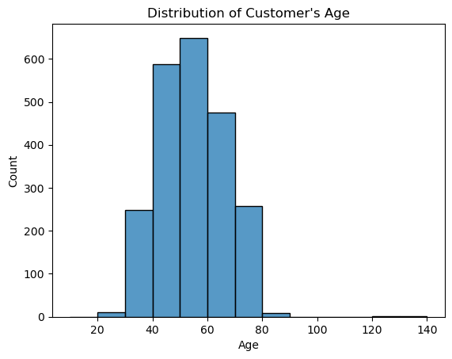

```python
sns.histplot(data=df, x="Age", bins = list(range(10, 150, 10)))
plt.title("Distribution of Customer's Age")
plt.savefig("Age.png");
```

It is seen that most of our customer's age distribution is within the range 41-60.

### $2. Education$

```python
df["Education"].unique()
```

```
array(['Graduation', 'PhD', 'Master', 'Basic', '2n Cycle'], dtype=object)
```

```python
df["Education"].value_counts()
```

```
Graduation    1127
PhD            486
Master         370
2n Cycle       203
Basic           54
Name: Education, dtype: int64
```

```python
df["Education"] = df["Education"].replace({"Graduation":"Graduate", "PhD":"Postgraduate", "Master":"Postgraduate", "2n Cycle":"Postgraduate", "Basic":"Undergraduate"})
```

```python
df["Education"].value_counts()
```

```
Graduate         1127
Postgraduate     1059
Undergraduate      54
Name: Education, dtype: int64
```

```python
df["Education"].unique()
```

```
array(['Graduate', 'Postgraduate', 'Undergraduate'], dtype=object)
```

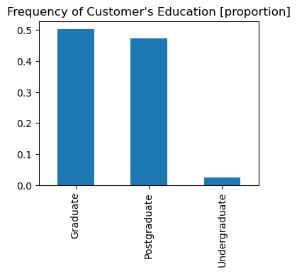

```python
df["Education"].value_counts(normalize=True).plot.bar(figsize=(4, 3))

plt.title("Frequency of Customer's Education [proportion]");
plt.savefig("Education [proportion].png");
```

```
Half of our customer's highest education level -> first degree graduation.
About 50% of customers have their education level at bachelour's degree which is then followed by customers with postgraduate level of education.
```

### $3. Marital Status$

```python
df["Marital_Status"].unique()
```

```
array(['Single', 'Together', 'Married', 'Divorced', 'Widow', 'Alone',
       'Absurd', 'YOLO'], dtype=object)
```

```python
df["Marital_Status"] = df["Marital_Status"].replace({"Together":"Married", "Absurd":"Single", "Divorced":"Single", "Alone":"Single", "YOLO":"Single", "Widow":"Single"})
```

```python
df["Marital_Status"].unique()
```

```
array(['Single', 'Married'], dtype=object)
```

```python
fig = px.bar(
    df["Marital_Status"].value_counts(normalize=True),
    title = "Proportion of Customer's Marital Status"
)
fig.update_layout(yaxis_title = "Freuency [proportion]")
fig.show()
```

[interactive chart not shown]

close to 65% of customers are married while the remaining close to 35% are single

### $4.Income$

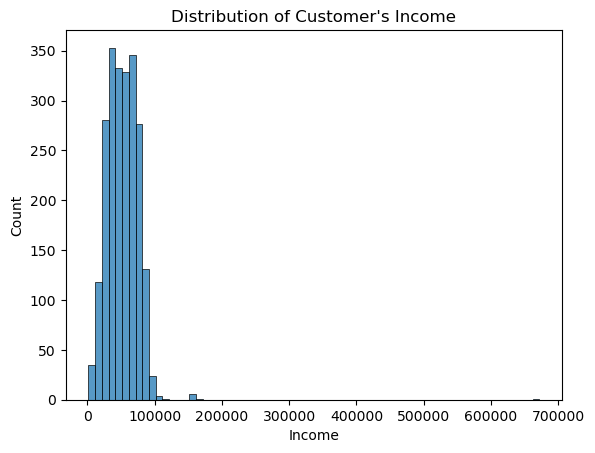

```python
sns.histplot(data=df, x="Income", binwidth=1e4)
plt.title("Distribution of Customer's Income");
```

It is seen that majority of customer's income is within 0-100k. However we have other customer's that earn way more than that (above 600k)

### $5a.Kid Home$

```python
df["Kidhome"].unique()
```

```
array([0, 1, 2], dtype=int64)
```

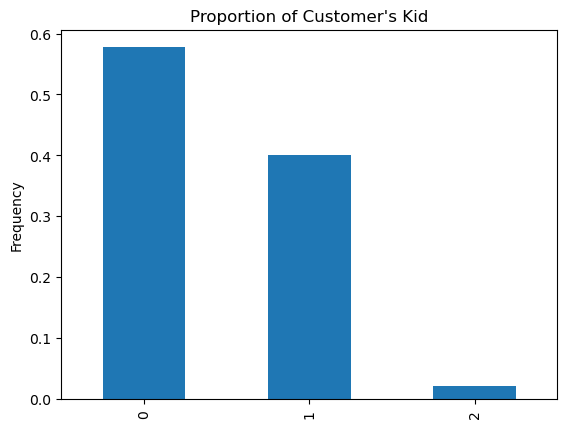

```python
df["Kidhome"].value_counts(normalize=True).plot.bar()
plt.ylabel("Frequency")
plt.title("Proportion of Customer's Kid");
```

Majority of customer's do not have kids at home

### $5b.Teen Home$

```python
df["Teenhome"].unique()
```

```
array([0, 1, 2], dtype=int64)
```

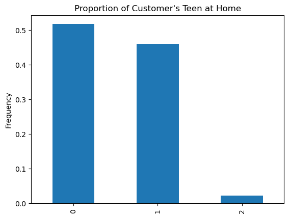

```python
df["Teenhome"].value_counts(normalize=True).plot.bar()
plt.ylabel("Frequency")
plt.title("Proportion of Customer's Teen at Home");
```

Majority of customer's do not have teen at home.

### $5.Total Children$

```python
df["Total Children"] = df["Kidhome"] + df["Teenhome"]

df["Total Children"].unique()
```

```
array([0, 2, 1, 3], dtype=int64)
```

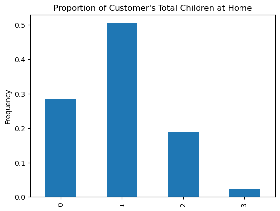

```python
df["Total Children"].value_counts(normalize=True).sort_index().plot.bar()
plt.ylabel("Frequency")
plt.title("Proportion of Customer's Total Children at Home");
```

Close to half of entire customers have the total number of 1 children, while in the remaining half above quarter of customers have no children at all.

### $6.Total Spent$

```python
df["TotalAmountSpent"].describe()
```

```
count    2240.000000
mean      605.798214
std       602.249288
min         5.000000
25%        68.750000
50%       396.000000
75%      1045.500000
max      2525.000000
Name: TotalAmountSpent, dtype: float64
```

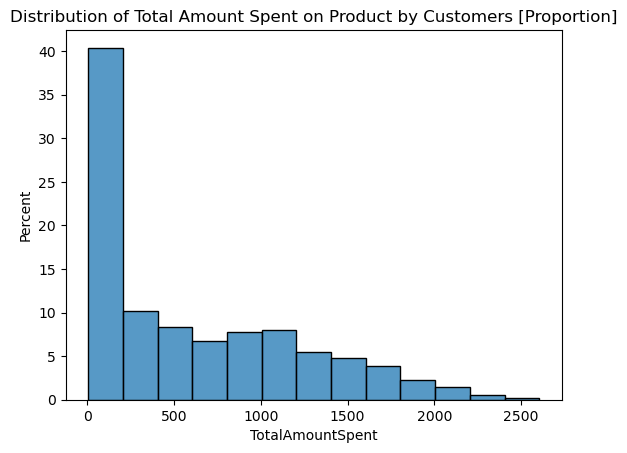

```python
sns.histplot(data=df, x="TotalAmountSpent", binwidth=200, stat="percent")
plt.title("Distribution of Total Amount Spent on Product by Customers [Proportion]");
```

close to half of customers total amount spent on the companies product is with 0 to 200.

# Bivariate Analysis

## 1.Age VS Total Amount Spent

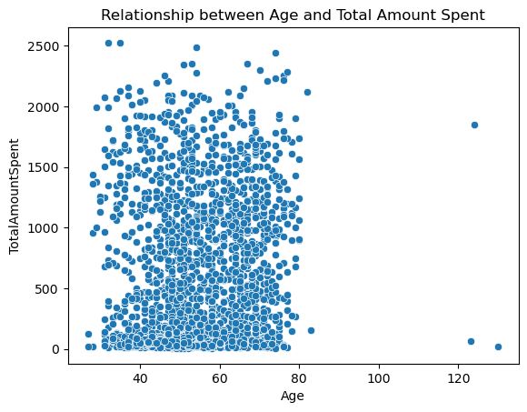

```python
sns.scatterplot(data=df, x="Age", y="TotalAmountSpent")
plt.title("Relationship between Age and Total Amount Spent");
```

There is less positive correlation between age and total amount spent (ie. age does not infer the total amount of money that will be spent by customers)

```python
def group_age(age):
    if age <20:
        return "11-20"
    elif age > 20 and age <31:
        return "21-30"
    elif age > 30 and age <41:
        return "31-40"
    elif age > 40 and age <51:
        return "41-50"
    elif age > 50 and age <61:
        return "51-60"
    elif age > 60 and age <71:
        return "61-70"
    elif age > 70 and age <81:
        return "71-80"
    elif age > 80:
        return ">80"

df["Age Group"] =df["Age"].apply(group_age)

order = ["21-30", "31-40", "41-50", "51-60", "61-70", "71-80", ">80"]
```

```python
mask = df.groupby("Age Group")["TotalAmountSpent"].median()
mask = mask.reset_index()
fig = px.bar(data_frame=mask, x="Age Group", y="TotalAmountSpent", height=400)
fig.update_xaxes(categoryorder='array',categoryarray= order)

fig.show()
```

[interactive chart not shown]

The group who spend most on average is customers within the range of 21-30, which is then followed by customers in the age range of 71-80.

## 2. Age VS Income

```python
mask = df.groupby("Age Group")["Income"].mean()
mask = mask.reset_index()
fig = px.bar(data_frame=mask, x="Age Group", y="Income")
fig.update_xaxes(categoryorder='array', categoryarray= ["21-30", "31-40"])

fig.show()
```

[interactive chart not shown]

The age group that earns more on average are the customers within above 80+, followed by customers within 71-80. Apart from customer age within 21-30. We can see a trend which postulates that as the age group increases so do the Income.

## 3.Education VS Total Amount Spent

```python
mask = df.groupby("Education")["TotalAmountSpent"].median()
mask = mask.reset_index()
fig = px.bar(data_frame=mask, x="Education", y="TotalAmountSpent",
            title = "Relationsip Between Education and Total Amount Spent [Average Spent]")
fig.update_xaxes(categoryorder='array', categoryarray= order)

fig.show()
```

[interactive chart not shown]

There isn't much difference between average spent for both graduate and Postgradute customer. However we see much drop for customers who have undergraduate. We can postulate that customers who have Graduate level and above spends approximately 7 times than customers who are undergraduate

## 4.Education VS Income

```python
mask = df.groupby("Education")["Income"].mean()
mask = mask.reset_index()
fig = px.bar(data_frame=mask, x="Education", y="Income",
            title = "Relationsip Between Customer's Education Level and Income [Average Income]")
fig.update_xaxes(categoryorder='array', categoryarray= order)

fig.show()
```

[interactive chart not shown]

Customers with Graduate and Post graduate education level earns 2 times above than customers who have undergraduate education level

## 5.Marital VS Total Amount Spent

```python
mask = df.groupby("Marital_Status")["TotalAmountSpent"].median()
mask = mask.reset_index()
fig = px.bar(data_frame=mask, x="Marital_Status", y="TotalAmountSpent", height=500,
             title="Relationship between Customer's Marital Status and Total Amount Spent [Average Spent]")
fig.update_xaxes(categoryorder='array', categoryarray= ["21-30", "31-40"])

fig.show()
```

[interactive chart not shown]

There isn't relationship between customer's marital status and the average amount spent.

## 6.Marital Status and Income

```python
mask = df.groupby("Marital_Status")["Income"].mean()
mask = mask.reset_index()
fig = px.bar(data_frame=mask, x="Marital_Status", y="Income", height=500,
             title="Relationship between Customer's Marital Status and Income [Average Income]")
fig.update_xaxes(categoryorder='array', categoryarray= ["21-30", "31-40"])

fig.show()
```

[interactive chart not shown]

Also In terms of Marital Status and Income there isn't relationship concerning that. Customer's earn approximately equall

## 7.Kid's Home VS Total Amount Spent.

```python
df["Kidhome"].value_counts()
```

```
0    1293
1     899
2      48
Name: Kidhome, dtype: int64
```

```python
df["Kidhome"].count()
```

```
2240
```

```python
mask = df.groupby("Kidhome")["TotalAmountSpent"].median()
mask = mask.reset_index()
fig = px.bar(data_frame=mask, x="Kidhome", y="TotalAmountSpent", height=500,
             title="Relationship between Customer's Kid and Amount Spent [Average]")
fig.update_xaxes(categoryorder='array', categoryarray= ["21-30", "31-40"])

fig.show()
```

[interactive chart not shown]

Customer's who don't have kids at home spend way high than those who have. They spend about 12 times than others on average.

## 8.Kid's Home VS Income

```python
mask = df.groupby("Kidhome")["Income"].mean()
mask = mask.reset_index()
fig = px.bar(data_frame=mask, x="Kidhome", y="Income", title="Relationship between Marital Status and Total Amount Spent")
fig.update_xaxes(categoryorder='array', categoryarray= ["21-30", "31-40"])

fig.show()
```

[interactive chart not shown]

We can see that customer's who don't have kids earn more than others.

## 9.Teen Homes VS Total Amount Spent

```python
mask = df.groupby("Teenhome")["TotalAmountSpent"].median()
mask = mask.reset_index()
fig = px.bar(data_frame=mask, x="Teenhome", y="TotalAmountSpent",
             title="Relationship between Marital Status and Total Amount Spent")

fig.show()
```

[interactive chart not shown]

The number of teens increase so do the average amount spent increases.

## 10.Teen's Home VS Income

```python
mask = df.groupby("Teenhome")["Income"].mean()
mask = mask.reset_index()
fig = px.bar(data_frame=mask, x="Teenhome", y="Income",
             title="Relationship between Marital Status and Total Amount Spent")

fig.show()
```

[interactive chart not shown]

Also It happens from the above summary that there is little trend in terms of average income collected.

## 11.Total Children VS Amount Spent.

```python
mask = df.groupby("Total Children")["TotalAmountSpent"].median()
mask = mask.reset_index()
fig = px.bar(data_frame=mask, x="Total Children", y="TotalAmountSpent",
             title="Relationship between Marital Status and Amount Spent [Average Spent]")

fig.show()
```

[interactive chart not shown]

## 12.Income VS Total AmountSpent

```python
fig = px.scatter(data_frame=df, x="Income",
                 y="TotalAmountSpent",
                 title="Relationship Between Customer's Income and Total Amount Spent")
fig.show()
```

[interactive chart not shown]

Income of a customers really determine the total amount to be spend on product. As a customer's income increase so do what they buy increases.

# Multivariate Analysis

### Education VS Income VS TotalAmountSpent

```python
fig = px.scatter(
    data_frame=df,
    x = "Income",
    y= "TotalAmountSpent",
    title = "Relationship between Income VS Total Amount Spent Based on Education",
    color = "Education"
)
fig.show()
```

[interactive chart not shown]

Undergraduates customers earn little than other customers that's why they spend little less

## Income VS Total Amount Spent VS Total Children

```python
fig = px.scatter(
    data_frame=df,
    x = "Income",
    y= "TotalAmountSpent",
    title = "Relationship between Income VS Total Amount Spent Based on Total children",
    color = "Total Children"
)
fig.show()
```

[interactive chart not shown]

# KMeans Model

```
Kmeans Model using two Features to Segment the Customers Demographic and Behaviour "Income" and "Total Amount Spent"
```

```python
data = df[["Income", "TotalAmountSpent"]]

df_log = np.log(data)
```

```python
std_scaler = StandardScaler()
df_scaled = std_scaler.fit_transform(df_log)

errors = []
for k in range(1, 11):
    model = KMeans(n_clusters=k, random_state=42)
    model.fit(df_scaled)
    errors.append(model.inertia_)
```

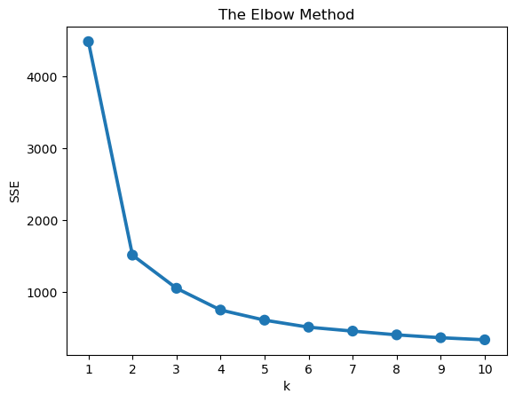

```python
plt.title('The Elbow Method')
plt.xlabel('k'); plt.ylabel('SSE')
sns.pointplot(x=list(range(1, 11)), y=errors)
plt.savefig("Elbow.png")
```

```python
model = KMeans(n_clusters=3, random_state=42)
model.fit(df_scaled)
```

```
KMeans(n_clusters=3, random_state=42)
```

```python
data = data.assign(ClusterLabel= model.labels_)
data.groupby("ClusterLabel")[["Income", "TotalAmountSpent"]].median()
```

| ClusterLabel | Income | TotalAmountSpent |
| --- | --- | --- |
| 0 | 62813.5 | 822.5 |
| 1 | 31801.0 | 54.0 |
| 2 | 67401.5 | 1001.0 |

### Interpreting the cluster Label.

```
Cluster 0: Customers - moderate Income and Moderate spending
Cluster 1: Custoemers - low Income and Low spending
Cluster 2: Customers - high income and high spending
```

```python
fig = px.scatter(
    data_frame=data,
    x = "Income",
    y= "TotalAmountSpent",
    title = "Relationship between Income VS Total Amount Spent",
    color = "ClusterLabel"
)
fig.show()
```

[interactive chart not shown]

# Building The Kmeans Model with Three Features

```python
data = df[["Age", "Income", "TotalAmountSpent"]]

df_log = np.log(data)
std_scaler = StandardScaler()
df_scaled = std_scaler.fit_transform(df_log)

sse = {}
for k in range(1, 11):
    model = KMeans(n_clusters=k, random_state=42)
    model.fit(df_scaled)
    sse[k] = model.inertia_
```

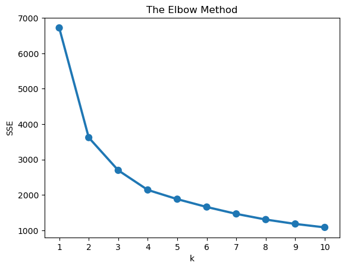

```python
plt.title('The Elbow Method')
plt.xlabel('k'); plt.ylabel('SSE')
sns.pointplot(x=list(sse.keys()), y=list(sse.values()))
plt.show()
```

```python
model = KMeans(n_clusters=4, random_state=42)
model.fit(df_scaled)

data = data.assign(ClusterLabel= model.labels_)
```

```python
result = data.groupby("ClusterLabel").agg({"Age":"mean", "Income":"median", "TotalAmountSpent":"median"}).round()

result
```

| ClusterLabel | Age | Income | TotalAmountSpent |
| --- | --- | --- | --- |
| 0 | 45.0 | 67023.0 | 990.0 |
| 1 | 57.0 | 37284.0 | 61.0 |
| 2 | 42.0 | 24440.0 | 54.0 |
| 3 | 66.0 | 64124.0 | 902.0 |

### Interpreting the cluster label

```
Cluster 0: Middle Age - High Income and High Spending
Cluster 1: Old Age - Low Income Low Spend
Cluster 2: Middle Age - Low Income and Low Spending
Cluster 3: Old Age - High Income and High Spending
```

## Result

```python
fig = px.scatter_3d(data_frame=data, x="Income",
                    y="TotalAmountSpent", z="Age", color="ClusterLabel",
                   title = "Visualizing Cluster Result Using 3 Features")
fig.show()
```

[interactive chart not shown]

## Final Result

[output not shown]